# Head motion and sociodemographics as independent correlates of retention:

2025-09-02

## 1. load required packages

```r
# Load required packages with error handling
required_packages <- c(
  "lme4", "dplyr", "broom", "bayestestR", "ggplot2", "stats", "e1071", "tidyr",
  "patchwork", "multcomp", "lmerTest", "broom.mixed", "tableone", "flextable",
  "officer", "readr", "jsonlite", "BayesFactor", "MuMIn", "brms", "consort", "ggplotify",
  "officer", "readr", "jsonlite", "BayesFactor", "MuMIn", "brms", "ggplotify",
  "ggeffects", "performance", "forcats"
)

for (pkg in required_packages) {
  if (!requireNamespace(pkg, quietly = TRUE)) {
    cat("Installing", pkg, "...\n")
    install.packages(pkg)
  }
  library(pkg, character.only = TRUE)
}
```

```
## ************
## Welcome to BayesFactor 0.9.12-4.7. If you have questions, please contact Richard Morey (richarddmorey@gmail.com).
##
## Type BFManual() to open the manual.
## ************
```

```
## Loading 'brms' package (version 2.22.0). Useful instructions
## can be found by typing help('brms'). A more detailed introduction
## to the package is available through vignette('brms_overview').
```

```r
cat("✓ All packages loaded successfully\n")
```

```
## ✓ All packages loaded successfully
```

## 2. configuration constraints

```r
# Configuration constants
CONFIG <- list(
  motion_threshold = 0.2,
  na_codes = c("777", "888", "999"),
  na_numeric = c(777, 888, 999), # 777 refuse to answer 888 decline to answer/question not asked 999 dont know
  data_dir = "/Users/ricard/Desktop/poldrack/projects/head-motion-exclusion/data",
  output_dir = "/Users/ricard/Desktop/poldrack/projects/head-motion-exclusion/outputs",
  data_path = "/Users/ricard/Desktop/poldrack/projects/head-motion-exclusion/data/df_final_included-refactored.rds",
  model_control = glmerControl(
    optimizer = "bobyqa",
    optCtrl = list(maxfun = 2e5)
  )
)

# Create output directory if needed
if (!dir.exists(CONFIG$output_dir)) {
  dir.create(CONFIG$output_dir, recursive = TRUE)
}

# Helper function to read ABCD CSV files
read_abcd_csv <- function(path, ...) {
  if (!file.exists(path)) {
    stop("File not found: ", path)
  }
  read_csv(path, na = CONFIG$na_codes, show_col_types = FALSE, ...)
}
```

## 3. prepare helper functions:

```r
# Helper function to prepare timepoint data (eliminates code duplication)
prepare_timepoint_data <- function(df, timepoint_name, timepoint_filter) {
  cat("Preparing", timepoint_name, "data...\n")

  initial_data <- df %>% filter(eventname == timepoint_filter)
  initial_n <- nrow(initial_data)

  # Check if 'exclude' column exists, if not use 'exclude_motion'
  exclude_col <- if("exclude" %in% names(initial_data)) "exclude" else "exclude_motion"

  processed_data <- initial_data %>%
    dplyr::select(src_subject_id, income, parental_education, sex, race_ethnicity_label,
                  all_of(exclude_col), rel_family_id, rsfmri_meanmotion, eventname,
                  site, age, imgincl_rsfmri_include) %>%
    rename(exclude = all_of(exclude_col)) %>%
    mutate(
      # Convert scale() matrices to numeric vectors (fixes model issues)
      income_z = as.numeric(scale(income)),
      parent_ed_z = as.numeric(scale(parental_education)),
      age_z = as.numeric(scale(age)),

      # Create clear binary coding
      female = ifelse(sex == 2, 1, 0),

      # Ensure proper factor coding
      race_ethnicity_label = as.factor(race_ethnicity_label),
      site = as.factor(site)
    )

  # Remove missing data with reporting
  complete_data <- processed_data %>% drop_na()
  final_n <- nrow(complete_data)
  removed_n <- initial_n - final_n

  cat("✓", timepoint_name, ":", initial_n, "→", final_n,
      "participants (", removed_n, "removed due to missing data)\n")

  return(complete_data)
}

# Helper function to check model convergence
check_model_convergence <- function(model, model_name) {
  convergence_code <- model@optinfo$conv$opt
  if (convergence_code != 0) {
    warning(paste(model_name, "did not converge (code:", convergence_code, ")"))
    return(FALSE)
  } else {
    cat("✓", model_name, "converged successfully\n")
    return(TRUE)
  }
}

# Helper function to perform model comparison
perform_model_comparison <- function(full_model, reduced_model, comparison_name) {
  cat("\n=== ", comparison_name, " ===\n")

  # Likelihood ratio test
  lrt_results <- anova(full_model, reduced_model)
  print(lrt_results)

  # Extract results
  chi_sq <- lrt_results$Chisq[2]
  df_diff <- lrt_results$Df[2]
  p_value <- lrt_results$`Pr(>Chisq)`[2]

  cat("\nLRT Results:\n")
  cat("χ²(", df_diff, ") = ", round(chi_sq, 2), ", p = ", round(p_value, 4), "\n", sep = "")

  # Bayesian comparison
  tryCatch({
    bf_results <- bayesfactor_models(full_model, reduced_model)
    bf_value <- as.numeric(bf_results$BF[1])
    cat("Bayes Factor: BF₁₀ = ", round(bf_value, 2), "\n", sep = "")

    return(list(p_value = p_value, bf_value = bf_value, chi_sq = chi_sq, df = df_diff))
  }, error = function(e) {
    cat("⚠️ Bayesian comparison failed:", e$message, "\n")
    return(list(p_value = p_value, chi_sq = chi_sq, df = df_diff))
  })
}

# Helper function to create odds ratio data for plotting
extract_odds_ratios <- function(model, model_name) {
  tryCatch({
    or_data <- broom.mixed::tidy(model, effects = "fixed", conf.int = TRUE, exponentiate = TRUE) %>%
      filter(grepl("race_ethnicity_label", term)) %>%
      mutate(
        race_ethnicity_label = gsub("race_ethnicity_label", "", term),
        model = model_name
      )

    # Select only the columns we need
    or_data <- or_data %>%
      dplyr::select(race_ethnicity_label, estimate, conf.low, conf.high, model)

    return(or_data)
  }, error = function(e) {
    cat("⚠️ Failed to extract odds ratios for", model_name, ":", e$message, "\n")
    return(data.frame())
  })
}
```

## 4. data loading and preparation

```r
cat("=== Loading ABCD Data ===\n")
```

```
## === Loading ABCD Data ===
```

```r
# Validate file exists
if (!file.exists(CONFIG$data_path)) {
  stop("Data file not found: ", CONFIG$data_path)
}

# Load main dataset
df_final_included <- readRDS(CONFIG$data_path)
cat("✓ Loaded", nrow(df_final_included), "total records\n")
```

```
## ✓ Loaded 19136 total records
```

```r
# Prepare both timepoints using consistent function
baseline_data <- prepare_timepoint_data(
  df_final_included,
  "baseline",
  "baseline_year_1_arm_1"
)
```

```
## Preparing baseline data...
## ✓ baseline : 9374 → 8561 participants ( 813 removed due to missing data)
```

```r
followup_data <- prepare_timepoint_data(
  df_final_included,
  "followup",
  "2_year_follow_up_y_arm_1"
)
```

```
## Preparing followup data...
## ✓ followup : 6962 → 5789 participants ( 1173 removed due to missing data)
```

```r
# Create longitudinal dataset
common_subject_ids <- intersect(baseline_data$src_subject_id, followup_data$src_subject_id)
cat("✓", length(common_subject_ids), "subjects have both timepoints\n")
```

```
## ✓ 4658 subjects have both timepoints
```

```r
longitudinal_data <- bind_rows(
  baseline_data %>%
    filter(src_subject_id %in% common_subject_ids) %>%
    mutate(timepoint = "baseline"),
  followup_data %>%
    filter(src_subject_id %in% common_subject_ids) %>%
    mutate(timepoint = "followup")
)

# Add follow-up indicator to baseline data
baseline_data <- baseline_data %>%
  mutate(has_followup_data = src_subject_id %in% followup_data$src_subject_id)

cat("✓ Created longitudinal dataset:", nrow(longitudinal_data), "observations\n")
```

```
## ✓ Created longitudinal dataset: 9316 observations
```

```r
cat("✓", sum(baseline_data$has_followup_data), "baseline subjects have followup\n")
```

```
## ✓ 4658 baseline subjects have followup
```

## 5. retention models:

> > **We first examined the association between head motion and retention, adjusting for socioeconomic and demographic covariates. Starting with the most complex model, we tested the interaction between head motion and race, controlling for income, parental education, gender, and age (Supplemental Table S5). The interaction was not statistically significant (χ²(4) = 6.55, p = .16), and none of the individual interaction terms (of mean motion with each race category) had a significant p-value. Further, the Bayes factor strongly supported excluding the interaction (BF10 = 3.61e-07).**

```r
cat("=== retention analysis ===\n")
```

```
## === retention analysis ===
```

```r
# function that wants "has_followup_data" to be coded as 1/0, so I'm changing that here
baseline_data$has_followup_data <- as.numeric(baseline_data$has_followup_data)

# Test interaction between motion and race/ethnicity
cat("\n=== motion × race/ethnicity interaction test ===\n")
```

```
##
## === motion × race/ethnicity interaction test ===
```

```r
# Additive model
additive_model <- glmer(
  has_followup_data ~ income_z + parent_ed_z + rsfmri_meanmotion + race_ethnicity_label + female + age_z +
    (1 | rel_family_id) +
    (1 | site),
  data = baseline_data,
  family = binomial,
  control = CONFIG$model_control
)

# Interaction model
interaction_model <- glmer(
  has_followup_data ~ income_z + parent_ed_z + rsfmri_meanmotion * race_ethnicity_label + female + age_z +
    (1 | rel_family_id) +
    (1 | site),
  data = baseline_data,
  family = binomial,
  control = CONFIG$model_control
)

# compare models
interaction_comparison <- anova(additive_model, interaction_model, test = "F")
print(interaction_comparison)
```

```
## Data: baseline_data
## Models:
## additive_model: has_followup_data ~ income_z + parent_ed_z + rsfmri_meanmotion + race_ethnicity_label + female + age_z + (1 | rel_family_id) + (1 | site)
## interaction_model: has_followup_data ~ income_z + parent_ed_z + rsfmri_meanmotion * race_ethnicity_label + female + age_z + (1 | rel_family_id) + (1 | site)
##                   npar   AIC   BIC  logLik deviance  Chisq Df Pr(>Chisq)
## additive_model      12 11279 11364 -5627.7    11255
## interaction_model   16 11281 11394 -5624.4    11249 6.5508  4     0.1616
```

```r
# get bayes factor - bayesian comparison
tryCatch({
  bf_interaction <- bayesfactor_models(additive_model,interaction_model)
  print(bf_interaction)
}, error = function(e) {
  cat("⚠️ Interaction Bayesian comparison failed:", e$message, "\n")
})
```

```
## Bayes Factors for Model Comparison
##
##
## [interaction_model]
##
## Model
## income_z + parent_ed_z + rsfmri_meanmotion * race_ethnicity_label + female + age_z + (1 | rel_family_id) + (1 | site)
##
##       BF
## 3.61e-07
##
## * Against Denominator: [additive_model] income_z + parent_ed_z + rsfmri_meanmotion + race_ethnicity_label + female + age_z + (1 | rel_family_id) + (1 | site)
## *   Bayes Factor Type: BIC approximation
```

```r
# Full retention model with race/ethnicity
attrition_full_model <- glmer(
  has_followup_data ~ income_z + parent_ed_z + rsfmri_meanmotion + race_ethnicity_label + female + age_z +
    (1 | rel_family_id) +
    (1 | site),
  data = baseline_data,
  family = binomial,
  control = CONFIG$model_control
)

# Reduced retention model without race/ethnicity
attrition_reduced_model <- glmer(
  has_followup_data ~ income_z + parent_ed_z + rsfmri_meanmotion + female + age_z +
    (1 | rel_family_id) +
    (1 | site),
  data = baseline_data,
  family = binomial,
  control = CONFIG$model_control
)

# Check convergence
attrition_full_converged <- check_model_convergence(attrition_full_model, "retention full model")
```

```
## ✓ retention full model converged successfully
```

```r
attrition_reduced_converged <- check_model_convergence(attrition_reduced_model, "retention reduced model")
```

```
## ✓ retention reduced model converged successfully
```

```r
# Model comparison with BF output
if (attrition_full_converged && attrition_reduced_converged) {
  attrition_results <- perform_model_comparison(
    attrition_full_model,
    attrition_reduced_model,
    "retention model comparison"
  )

  # R-squared values
  cat("\nModel R-squared values:\n")
  r2_reduced <- MuMIn::r.squaredGLMM(attrition_reduced_model)
  r2_full <- MuMIn::r.squaredGLMM(attrition_full_model)

  cat("Reduced model R²:", round(r2_reduced[1], 3), "(marginal),", round(r2_reduced[2], 3), "(conditional)\n")
  cat("Full model R²:", round(r2_full[1], 3), "(marginal),", round(r2_full[2], 3), "(conditional)\n")
} else {
  cat("⚠️ Cannot perform retention model comparison due to convergence issues\n")
}
```

```
##
## ===  retention model comparison  ===
## Data: baseline_data
## Models:
## reduced_model: has_followup_data ~ income_z + parent_ed_z + rsfmri_meanmotion + female + age_z + (1 | rel_family_id) + (1 | site)
## full_model: has_followup_data ~ income_z + parent_ed_z + rsfmri_meanmotion + race_ethnicity_label + female + age_z + (1 | rel_family_id) + (1 | site)
##               npar   AIC   BIC  logLik deviance  Chisq Df Pr(>Chisq)
## reduced_model    8 11301 11358 -5642.5    11285
## full_model      12 11279 11364 -5627.7    11255 29.637  4  5.801e-06 ***
## ---
## Signif. codes:  0 '***' 0.001 '**' 0.01 '*' 0.05 '.' 0.1 ' ' 1
##
## LRT Results:
## χ²(4) = 29.64, p = 0
## Bayes Factor: BF₁₀ =
##
## Model R-squared values:
```

```
## Reduced model R²: 0.015 (marginal), 0.013 (conditional)
## Full model R²: 0.02 (marginal), 0.018 (conditional)
```

## retention full model summary

```r
summary(attrition_full_model)
```

```
## Generalized linear mixed model fit by maximum likelihood (Laplace
##   Approximation) [glmerMod]
##  Family: binomial  ( logit )
## Formula: has_followup_data ~ income_z + parent_ed_z + rsfmri_meanmotion +
##     race_ethnicity_label + female + age_z + (1 | rel_family_id) +
##     (1 | site)
##    Data: baseline_data
## Control: CONFIG$model_control
##
##      AIC      BIC   logLik deviance df.resid
##  11279.4  11364.0  -5627.7  11255.4     8549
##
## Scaled residuals:
##     Min      1Q  Median      3Q     Max
## -1.7124 -0.8524  0.5576  0.7442  1.7111
##
## Random effects:
##  Groups        Name        Variance Std.Dev.
##  rel_family_id (Intercept) 0.6733   0.8205
##  site          (Intercept) 0.2836   0.5325
## Number of obs: 8561, groups:  rel_family_id, 7298; site, 21
##
## Fixed effects:
##                              Estimate Std. Error z value Pr(>|z|)
## (Intercept)                   0.38369    0.12944   2.964 0.003034 **
## income_z                      0.08839    0.03731   2.369 0.017822 *
## parent_ed_z                   0.06653    0.03752   1.773 0.076193 .
## rsfmri_meanmotion            -0.46108    0.12272  -3.757 0.000172 ***
## race_ethnicity_labelBlack    -0.46876    0.09509  -4.929 8.25e-07 ***
## race_ethnicity_labelHispanic -0.08462    0.08483  -0.998 0.318516
## race_ethnicity_labelAsian    -0.38015    0.19768  -1.923 0.054480 .
## race_ethnicity_labelOther    -0.22751    0.09005  -2.527 0.011519 *
## female                       -0.19996    0.05209  -3.838 0.000124 ***
## age_z                        -0.05757    0.02616  -2.201 0.027738 *
## ---
## Signif. codes:  0 '***' 0.001 '**' 0.01 '*' 0.05 '.' 0.1 ' ' 1
##
## Correlation of Fixed Effects:
##             (Intr) incm_z prnt__ rsfmr_ rc_t_B rc_t_H rc_t_A rc_t_O female
## income_z    -0.045
## parent_ed_z -0.051 -0.554
## rsfmr_mnmtn -0.235  0.016  0.029
## rc_thncty_B -0.154  0.285  0.069 -0.026
## rc_thncty_H -0.175  0.131  0.177 -0.045  0.316
## rc_thncty_A -0.063  0.030 -0.055 -0.008  0.072  0.114
## rc_thncty_O -0.130  0.103  0.015 -0.013  0.235  0.248  0.092
## female      -0.220 -0.010  0.000  0.093 -0.009 -0.009 -0.006 -0.006
## age_z       -0.036 -0.010  0.013  0.120 -0.005  0.006 -0.012  0.002  0.049
```

## retention reduced model summary

```r
summary(attrition_reduced_model)
```

```
## Generalized linear mixed model fit by maximum likelihood (Laplace
##   Approximation) [glmerMod]
##  Family: binomial  ( logit )
## Formula: has_followup_data ~ income_z + parent_ed_z + rsfmri_meanmotion +
##     female + age_z + (1 | rel_family_id) + (1 | site)
##    Data: baseline_data
## Control: CONFIG$model_control
##
##      AIC      BIC   logLik deviance df.resid
##  11301.0  11357.5  -5642.5  11285.0     8553
##
## Scaled residuals:
##     Min      1Q  Median      3Q     Max
## -1.6621 -0.8524  0.5612  0.7509  1.8084
##
## Random effects:
##  Groups        Name        Variance Std.Dev.
##  rel_family_id (Intercept) 0.6724   0.8200
##  site          (Intercept) 0.2950   0.5432
## Number of obs: 8561, groups:  rel_family_id, 7298; site, 21
##
## Fixed effects:
##                   Estimate Std. Error z value Pr(>|z|)
## (Intercept)        0.27782    0.12842   2.163   0.0305 *
## income_z           0.14410    0.03565   4.042 5.30e-05 ***
## parent_ed_z        0.07073    0.03678   1.923   0.0545 .
## rsfmri_meanmotion -0.48174    0.12242  -3.935 8.32e-05 ***
## female            -0.20574    0.05202  -3.955 7.66e-05 ***
## age_z             -0.05921    0.02612  -2.267   0.0234 *
## ---
## Signif. codes:  0 '***' 0.001 '**' 0.01 '*' 0.05 '.' 0.1 ' ' 1
##
## Correlation of Fixed Effects:
##             (Intr) incm_z prnt__ rsfmr_ female
## income_z     0.008
## parent_ed_z -0.024 -0.617
## rsfmr_mnmtn -0.246  0.027  0.038
## female      -0.224 -0.007  0.001  0.093
## age_z       -0.036 -0.010  0.011  0.120  0.049
```

## 6. bayes factors for retention models

# return bayes factor for individual race predictors

**To further evaluate the importance of individual race categories, we calculated Bayes factors comparing models that combined each specific race group with White versus the full model that treated all race categories separately. The Bayes factor for Black was 2189.6, indicating strong evidence that Black participants should be modeled separately from White participants. In contrast, Hispanic, Asian, and Other groups showed BF10 values of 0.0177, 0.068, and 0.256 respectively, indicating little evidence to model these categories separately.**

```r
race_levels <- levels(baseline_data$race_ethnicity_label)
race_levels <- race_levels[race_levels != "White"]  # exclude White since it's the reference

bf_results <- numeric(length(race_levels))
names(bf_results) <- race_levels

for (race in race_levels) {

  # create new factor variable that equates to omitting
  # the dummy for the specified level `race`
  baseline_data$race_new_baseline = baseline_data$race_ethnicity_label
  baseline_data$race_new_baseline <- fct_collapse(
      baseline_data$race_new_baseline,
      White_TestedRace = c("White", race)
      )
  # Ensure the baseline is White_TestedRace
  baseline_data$race_new_baseline <- fct_relevel(
      baseline_data$race_new_baseline,
    "White_TestedRace"
    )

  # Fit reduced model without the race category separated from White
  model_reduced <- glmer(
    has_followup_data ~ income_z + parent_ed_z + rsfmri_meanmotion +
      race_new_baseline + female + age_z + (1 | rel_family_id) + (1 | site),
    data = baseline_data,
    family = binomial,
    control = CONFIG$model_control
  )

  # Compute Bayes factor comparing full model to reduced model
 bf_out <- bayesfactor_models(attrition_full_model, model_reduced,
                             denominator = model_reduced)

  # Extract BF (exponentiate log_BF)
  bf_val <- exp(bf_out$log_BF[1])
  bf_results[race] <- bf_val
}

bf_results
```

```
##        Black     Hispanic        Asian        Other
## 2.189635e+03 1.770043e-02 6.832911e-02 2.560389e-01
```

**A likelihood ratio test comparing the full model (including all race indicators) to a reduced model (excluding race) also supported the inclusion of race overall (χ²(4) = 29.6, p = < 0.001). However, a BIC-based Bayes factor comparing these two models yielded BF10 ≈ 0.04 in favor of the reduced model, suggesting that from a Bayesian model selection perspective, including all race indicators may not be justified by the increase in model complexity. The parameter estimates for other covariates were similar in the reduced model (Table 1, right side).**

```r
# BIC-BF for full vs reduced model
bf_race = bayesfactor_models(
  attrition_full_model, attrition_reduced_model,
  denominator = attrition_reduced_model
   )

# Careful!  This is choosing the first model entered vs denom.
 bf_race_val = exp(bf_race$log_BF[1])
 sprintf("BIC-BF for model with race vs without race: %.2f", bf_race_val)
```

```
## [1] "BIC-BF for model with race vs without race: 0.04"
```

# BIC-BF for income, parent education, motion, sex female, and age attrition models - full and reduced)

# Full model:

```r
#' Calculate Bayes Factors for individual predictors in a mixed model.
#'
#' This function compares a full model to several reduced models,
#' each with one predictor removed, to calculate the Bayes Factor (BF10)
#' for the inclusion of that predictor.
#'
#' @param full_formula The formula for the full model.
#' @param predictors_to_test A character vector of predictor names to test.
#' @param data The dataframe containing the data.
#' @param ... Additional arguments to be passed to the glmer function
#'            (e.g., family, control).
#'
#' @return A named list where each element is a 'bayesfactor_models' object
#'         for the corresponding tested predictor.
#'
calculate_bf_for_predictors <- function(full_formula, predictors_to_test, data, ...) {

  # --- 1. Fit the full model (only once) ---
  message("Fitting the full model...")
  full_model <- glmer(full_formula, data = data, ...)

  # --- 2. Loop through each predictor to test ---
  # 'lapply' will create a list of results for us.
  results_list <- lapply(predictors_to_test, function(predictor) {

    message(paste("Calculating BF for:", predictor))

    # --- 3. Create the formula for the reduced model ---
    # The update() function is perfect for programmatically removing a term.
    # The formula `~ . - predictor` means "keep everything the same, but remove this predictor".
    reduced_formula <- update(full_formula, as.formula(paste("~ . -", predictor)))

    # --- 4. Fit the reduced model ---
    reduced_model <- glmer(reduced_formula, data = data, ...)

    # --- 5. Calculate the Bayes Factor ---
    # The full model is the numerator, the reduced model is the denominator.
    bf <- bayesfactor_models(
      full_model,
      reduced_model,
      denominator = reduced_model
    )

    return(bf)
  })

  # --- 6. Name the list elements for easy access ---
  names(results_list) <- predictors_to_test

  return(results_list)
}

# --- 1. Define the full model formula ---
attrition_formula <- formula(
  has_followup_data ~ income_z + parent_ed_z + rsfmri_meanmotion +
                      race_ethnicity_label + female + age_z +
                      (1 | rel_family_id) + (1 | site)
)

# --- 2. Define the list of predictors you want to test ---
predictors <- c("income_z", "parent_ed_z", "rsfmri_meanmotion", "female", "age_z")

# --- 3. Run the function! ---
all_bfs <- calculate_bf_for_predictors(
  full_formula = attrition_formula,
  predictors_to_test = predictors,
  data = baseline_data,
  family = binomial,
  control = CONFIG$model_control
)
```

```
## Fitting the full model...
```

```
## Calculating BF for: income_z
```

```
## Calculating BF for: parent_ed_z
```

```
## Calculating BF for: rsfmri_meanmotion
```

```
## Calculating BF for: female
```

```
## Calculating BF for: age_z
```

```r
# --- 4. View the results for retention full model (Table 1) BF10 ---

# Get the BF10 for income
all_bfs$income_z
```

```
## Bayes Factors for Model Comparison
##
##
## [full_model]
##
## Model
## income_z + parent_ed_z + rsfmri_meanmotion + race_ethnicity_label + female + age_z + (1 | rel_family_id) + (1 | site)
##
##    BF
## 0.176
##
## * Against Denominator: [reduced_model] parent_ed_z + rsfmri_meanmotion + race_ethnicity_label + female + age_z + (1 | rel_family_id) + (1 | site)
## *   Bayes Factor Type: BIC approximation
```

```r
# Get the BF10 for parental education
all_bfs$parent_ed_z
```

```
## Bayes Factors for Model Comparison
##
##
## [full_model]
##
## Model
## income_z + parent_ed_z + rsfmri_meanmotion + race_ethnicity_label + female + age_z + (1 | rel_family_id) + (1 | site)
##
##    BF
## 0.051
##
## * Against Denominator: [reduced_model] income_z + rsfmri_meanmotion + race_ethnicity_label + female + age_z + (1 | rel_family_id) + (1 | site)
## *   Bayes Factor Type: BIC approximation
```

```r
# Get the BF10 for motion
all_bfs$rsfmri_meanmotion
```

```
## Bayes Factors for Model Comparison
##
##
## [full_model]
##
## Model
## income_z + parent_ed_z + rsfmri_meanmotion + race_ethnicity_label + female + age_z + (1 | rel_family_id) + (1 | site)
##
##    BF
## 12.66
##
## * Against Denominator: [reduced_model] income_z + parent_ed_z + race_ethnicity_label + female + age_z + (1 | rel_family_id) + (1 | site)
## *   Bayes Factor Type: BIC approximation
```

```r
# Get the BF10 for sex (female)
all_bfs$female
```

```
## Bayes Factors for Model Comparison
##
##
## [full_model]
##
## Model
## income_z + parent_ed_z + rsfmri_meanmotion + race_ethnicity_label + female + age_z + (1 | rel_family_id) + (1 | site)
##
##    BF
## 16.82
##
## * Against Denominator: [reduced_model] income_z + parent_ed_z + rsfmri_meanmotion + race_ethnicity_label + age_z + (1 | rel_family_id) + (1 | site)
## *   Bayes Factor Type: BIC approximation
```

```r
# Get the BF10 for age
all_bfs$age_z
```

```
## Bayes Factors for Model Comparison
##
##
## [full_model]
##
## Model
## income_z + parent_ed_z + rsfmri_meanmotion + race_ethnicity_label + female + age_z + (1 | rel_family_id) + (1 | site)
##
##    BF
## 0.119
##
## * Against Denominator: [reduced_model] income_z + parent_ed_z + rsfmri_meanmotion + race_ethnicity_label + female + (1 | rel_family_id) + (1 | site)
## *   Bayes Factor Type: BIC approximation
```

# Reduced model:

```r
#' Calculate Bayes Factors for individual predictors in a REDUCED mixed model.
#'
#' This function compares a full model to several reduced models,
#' each with one predictor removed, to calculate the Bayes Factor (BF10)
#' for the inclusion of that predictor.
#'
#' @param full_formula The formula for the full model.
#' @param predictors_to_test A character vector of predictor names to test.
#' @param data The dataframe containing the data.
#' @param ... Additional arguments to be passed to the glmer function
#'            (e.g., family, control).
#'
#' @return A named list where each element is a 'bayesfactor_models' object
#'         for the corresponding tested predictor.
#'


calculate_bf_for_predictors <- function(full_formula, predictors_to_test, data, ...) {

  # --- 1. Fit the full model (only once) ---
  message("Fitting the full model...")
  full_model <- glmer(full_formula, data = data, ...)

  # --- 2. Loop through each predictor to test ---
  # 'lapply' will create a list of results for us.
  results_list <- lapply(predictors_to_test, function(predictor) {

    message(paste("Calculating BF for:", predictor))

    # --- 3. Create the formula for the reduced model ---
    # The update() function is perfect for programmatically removing a term.
    # The formula `~ . - predictor` means "keep everything the same, but remove this predictor".
    reduced_formula <- update(full_formula, as.formula(paste("~ . -", predictor)))

    # --- 4. Fit the reduced model ---
    reduced_model <- glmer(reduced_formula, data = data, ...)

    # --- 5. Calculate the Bayes Factor ---
    # The full model is the numerator, the reduced model is the denominator.
    bf <- bayesfactor_models(
      full_model,
      reduced_model,
      denominator = reduced_model
    )

    return(bf)
  })

  # --- 6. Name the list elements for easy access ---
  names(results_list) <- predictors_to_test

  return(results_list)
}

# --- 1. Define the reduced model formula ---
attrition_formula <- formula(
  has_followup_data ~ income_z + parent_ed_z + rsfmri_meanmotion +
                      female + age_z +
                      (1 | rel_family_id) + (1 | site)
)

# --- 2. Define the list of predictors you want to test ---
predictors <- c("income_z", "parent_ed_z", "rsfmri_meanmotion", "female", "age_z")

# --- 3. Run the function! ---
all_bfs <- calculate_bf_for_predictors(
  full_formula = attrition_formula,
  predictors_to_test = predictors,
  data = baseline_data,
  family = binomial,
  control = CONFIG$model_control
)
```

```
## Fitting the full model...
```

```
## Calculating BF for: income_z
```

```
## Calculating BF for: parent_ed_z
```

```
## Calculating BF for: rsfmri_meanmotion
```

```
## Calculating BF for: female
```

```
## Calculating BF for: age_z
```

```r
# --- 4. View the results for retention reduced models (Table 1) BF10 ---

# Get the BF10 for income
all_bfs$income_z
```

```
## Bayes Factors for Model Comparison
##
##
## [full_model]
##
## Model
## income_z + parent_ed_z + rsfmri_meanmotion + female + age_z + (1 | rel_family_id) + (1 | site)
##
##    BF
## 38.22
##
## * Against Denominator: [reduced_model] parent_ed_z + rsfmri_meanmotion + female + age_z + (1 | rel_family_id) + (1 | site)
## *   Bayes Factor Type: BIC approximation
```

```r
# Get the BF10 for parental education
all_bfs$parent_ed_z
```

```
## Bayes Factors for Model Comparison
##
##
## [full_model]
##
## Model
## income_z + parent_ed_z + rsfmri_meanmotion + female + age_z + (1 | rel_family_id) + (1 | site)
##
##    BF
## 0.068
##
## * Against Denominator: [reduced_model] income_z + rsfmri_meanmotion + female + age_z + (1 | rel_family_id) + (1 | site)
## *   Bayes Factor Type: BIC approximation
```

```r
# Get the BF10 for motion
all_bfs$rsfmri_meanmotion
```

```
## Bayes Factors for Model Comparison
##
##
## [full_model]
##
## Model
## income_z + parent_ed_z + rsfmri_meanmotion + female + age_z + (1 | rel_family_id) + (1 | site)
##
##    BF
## 25.36
##
## * Against Denominator: [reduced_model] income_z + parent_ed_z + female + age_z + (1 | rel_family_id) + (1 | site)
## *   Bayes Factor Type: BIC approximation
```

```r
# Get the BF10 for sex (female)
all_bfs$female
```

```
## Bayes Factors for Model Comparison
##
##
## [full_model]
##
## Model
## income_z + parent_ed_z + rsfmri_meanmotion + female + age_z + (1 | rel_family_id) + (1 | site)
##
##    BF
## 26.55
##
## * Against Denominator: [reduced_model] income_z + parent_ed_z + rsfmri_meanmotion + age_z + (1 | rel_family_id) + (1 | site)
## *   Bayes Factor Type: BIC approximation
```

```r
# Get the BF10 for age
all_bfs$age_z
```

```
## Bayes Factors for Model Comparison
##
##
## [full_model]
##
## Model
## income_z + parent_ed_z + rsfmri_meanmotion + female + age_z + (1 | rel_family_id) + (1 | site)
##
##    BF
## 0.138
##
## * Against Denominator: [reduced_model] income_z + parent_ed_z + rsfmri_meanmotion + female + (1 | rel_family_id) + (1 | site)
## *   Bayes Factor Type: BIC approximation
```

## 7. return odds ratios for full and reduced models

**We assessed the role of race/ethnicity in predicting follow-up participation using both frequentist and Bayesian approaches. Compared to White participants, the odds of retention were significantly lower for Black individuals (OR = 0.63, 95% CI [0.52, 0.75], p < .001) and for those in the Other race category (OR = 0.80, 95% CI [0.67, 0.95], p = .012), whereas no other race groups differed significantly from White participants. These effects are illustrated in Fig. 1 in terms of predicted probabilities (probability of retention), adjusted for all continuous covariates at their mean values for race/ethnicity and mean head motion.**

```r
extract_OR_table <- function(model) {
  # tidy output with confint
  tidy_mod <- broom.mixed::tidy(model, effects = "fixed", conf.int = TRUE, conf.level = 0.95)

  # compute OR and CIs
  tidy_mod <- tidy_mod %>%
    mutate(
      OR = exp(estimate),
      OR_low = exp(conf.low),
      OR_high = exp(conf.high),
      p_value = p.value
    ) %>%
    dplyr::select(term, OR, OR_low, OR_high, p_value)

  # remove intercept if you want
  tidy_mod <- tidy_mod %>% filter(term != "(Intercept)")

  return(tidy_mod)
}

# Extract tables
tbl_full <- extract_OR_table(attrition_full_model)
tbl_reduced <- extract_OR_table(attrition_reduced_model)

print(tbl_full) # full retention model (table 1)
```

```
## # A tibble: 9 × 5
##   term                            OR OR_low OR_high     p_value
##   <chr>                        <dbl>  <dbl>   <dbl>       <dbl>
## 1 income_z                     1.09   1.02    1.18  0.0178
## 2 parent_ed_z                  1.07   0.993   1.15  0.0762
## 3 rsfmri_meanmotion            0.631  0.496   0.802 0.000172
## 4 race_ethnicity_labelBlack    0.626  0.519   0.754 0.000000825
## 5 race_ethnicity_labelHispanic 0.919  0.778   1.09  0.319
## 6 race_ethnicity_labelAsian    0.684  0.464   1.01  0.0545
## 7 race_ethnicity_labelOther    0.797  0.668   0.950 0.0115
## 8 female                       0.819  0.739   0.907 0.000124
## 9 age_z                        0.944  0.897   0.994 0.0277
```

```r
print(tbl_reduced) # reduced retention model (table 1)
```

```
## # A tibble: 5 × 5
##   term                 OR OR_low OR_high   p_value
##   <chr>             <dbl>  <dbl>   <dbl>     <dbl>
## 1 income_z          1.16   1.08    1.24  0.0000530
## 2 parent_ed_z       1.07   0.999   1.15  0.0545
## 3 rsfmri_meanmotion 0.618  0.486   0.785 0.0000832
## 4 female            0.814  0.735   0.901 0.0000766
## 5 age_z             0.943  0.895   0.992 0.0234
```

## 8. calculate predicted probabilites by race/ethnicity to plot:

```r
# Get predicted probabilities by race/ethnicity
preds_race <- ggpredict(attrition_full_model, terms = "race_ethnicity_label")
```

```
## You are calculating adjusted predictions on the population-level (i.e.
##   `type = "fixed"`) for a *generalized* linear mixed model.
##   This may produce biased estimates due to Jensen's inequality. Consider
##   setting `bias_correction = TRUE` to correct for this bias.
##   See also the documentation of the `bias_correction` argument.
```

```r
print(preds_race)
```

```
## # Predicted probabilities of has_followup_data
##
## race_ethnicity_label | Predicted |     95% CI
## ---------------------------------------------
## White                |      0.55 | 0.49, 0.60
## Black                |      0.43 | 0.36, 0.50
## Hispanic             |      0.52 | 0.46, 0.59
## Asian                |      0.45 | 0.35, 0.56
## Other                |      0.49 | 0.42, 0.56
##
## Adjusted for:
## *          income_z =  0.00
## *       parent_ed_z =  0.06
## * rsfmri_meanmotion =  0.23
## *            female =  0.50
## *             age_z = -0.00
## *     rel_family_id = 0 (population-level)
## *              site = 0 (population-level)
```

```r
# motion
preds_motion <- ggpredict(attrition_full_model,
                   terms = "rsfmri_meanmotion [0:0.9 by=0.1]")

# View the predicted values
print(preds_motion)
```

```
## # Predicted probabilities of has_followup_data
##
## rsfmri_meanmotion | Predicted |     95% CI
## ------------------------------------------
##              0.00 |      0.57 | 0.51, 0.63
##              0.10 |      0.56 | 0.50, 0.62
##              0.20 |      0.55 | 0.49, 0.61
##              0.30 |      0.54 | 0.48, 0.60
##              0.50 |      0.51 | 0.45, 0.58
##              0.60 |      0.50 | 0.44, 0.57
##              0.70 |      0.49 | 0.43, 0.56
##              0.90 |      0.47 | 0.40, 0.54
##
## Adjusted for:
## *             income_z =  0.00
## *          parent_ed_z =  0.06
## * race_ethnicity_label = White
## *               female =  0.50
## *                age_z = -0.00
## *        rel_family_id = 0 (population-level)
## *                 site = 0 (population-level)
```

```
##
## Not all rows are shown in the output. Use `print(..., n = Inf)` to show
##   all rows.
```

## 9. plot the predicted probabilites:

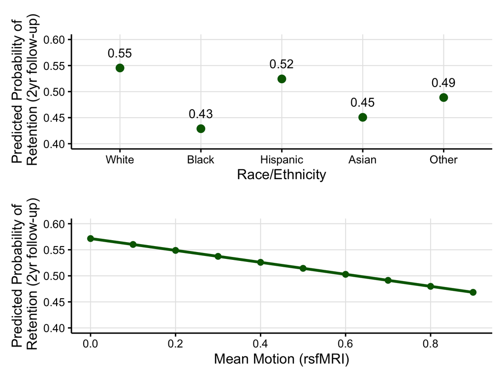

```r
# Use the same y-axis scale for both plots
y_limits <- c(0.4, 0.6)
y_breaks <- seq(0.4, 0.6, by = 0.05)

# Enhanced plot for race predictions (showing retention rate - higher is better)
p1 <- ggplot(preds_race, aes(x = x, y = predicted)) +
  geom_point(size = 4, color = "darkgreen") +
  geom_text(aes(label = sprintf("%.2f", predicted)),
            vjust = -1.2, size = 5, color = "black") +
  scale_y_continuous(limits = y_limits, breaks = y_breaks) +
  labs(
    x = "Race/Ethnicity",
    y = "Predicted Probability of\n Retention (2yr follow-up)",
    title = ""
  ) +
  theme_minimal(base_size = 16) +
  theme(
    axis.text = element_text(color = "black"),
    axis.title = element_text(color = "black"),
    axis.ticks = element_line(color = "black"),
    axis.line = element_line(color = "black"),
    panel.grid.major = element_line(color = "grey90", size = 0.5),
    panel.grid.minor = element_blank()
  )
# Enhanced plot for motion predictions
p2 <- ggplot(preds_motion, aes(x = x, y = predicted)) +
  geom_line(linewidth = 1.5, color = "darkgreen") +
  geom_point(size = 3, color = "darkgreen") +
  scale_x_continuous(breaks = pretty(preds_motion$x, n = 6)) +
  scale_y_continuous(limits = y_limits, breaks = y_breaks) +
  labs(
    x = "Mean Motion (rsfMRI)",
    y = "Predicted Probability of\n Retention (2yr follow-up)",  # Remove the y-axis title here
    title = ""
  ) +
  theme_minimal(base_size = 16) +
  theme(
    axis.text = element_text(color = "black"),
    axis.title = element_text(color = "black"),
    axis.ticks = element_line(color = "black"),
    axis.line = element_line(color = "black"),
    panel.grid.major = element_line(color = "grey90", size = 0.5),
    panel.grid.minor = element_blank()
  )

# Combine vertically with better spacing
combined_plot <- p1 / p2 + plot_layout(heights = c(1, 1))

# Display the plot
print(combined_plot)
```

```r
# Save as SVG
ggsave(
  filename = "prediction_plots.svg",
  plot = combined_plot,
  path = CONFIG$output_dir,
  width = 10,
  height = 6,
  units = "in"
)
```

## 10. Results Summary

**Taken together, these results illustrate the complexity of modeling race/ethnicity. Although the overall contribution of race to model fit is ambiguous across inferential frameworks, there is consistent and strong evidence that Black participants are substantially less likely to have follow-up data compared to white participants, even after adjusting for socioeconomic and demographic factors.**

```r
cat("=== Final Results Summary ===\n\n")
```

```
## === Final Results Summary ===
```

```r
# Sample sizes
cat("Sample Sizes:\n")
```

```
## Sample Sizes:
```

```r
cat("Baseline:", nrow(baseline_data), "participants\n")
```

```
## Baseline: 8561 participants
```

```r
cat("Follow-up:", nrow(followup_data), "participants\n")
```

```
## Follow-up: 5789 participants
```

```r
cat("Longitudinal:", length(common_subject_ids), "subjects with both timepoints (", nrow(longitudinal_data), "observations)\n")
```

```
## Longitudinal: 4658 subjects with both timepoints ( 9316 observations)
```

```r
cat("\n=== Analysis Complete ===\n")
```

```
##
## === Analysis Complete ===
```